# Gov 50 Final Project

My final project

Gloria Maldonado

## Project thoughts

The impact of the COVID-19 Pandemic was one that was seen worldwide. As countries, communities, and economies closed down; one of the sectors that was severely impacted was that of education. Schools closed down, many institutions moved to online courses, and students stopped interacting with others as much. The possibility of the pandemic heavily impacting the sector of education was one of my fears. Children in K-12 education may be susceptible to further impact because of their young age and potential hold it may cause to their learning schedules. In this project, I hope to analyze if the long-standing debate of Charter versus regular Public Schools. In this project, I am focusing on the Chicago Public Schools Network after having obtained access to their testing and School Records. In these data sets we are able to see the SAT averages of different schools within the CPS district including CPS Network schools which are CPS sponsored Public School and Charter Schools which will be the object of my focus. Do Charter Schools perform better than CPS Network Schools? How has Covid-19 impacted school performance through the measurement of SAT Composite Scores and Percentage of College Readiness? I hypothesize that Charter schools will outperform CPS Network Schools, and that the Covid 19 Pandemic will have minimal impacts on student performance. I believe this because Charter Schools receive an additional amount of funding from outside donors in addition to receiving federal funds as well; because they were founded to expand opportunities, I feel as if it would make sense to see them outperform the CPS Network Schools which may have less funding. I also believe that the cohort of highschoolers who took the SAT shouldn’t be heaving affected by the change in teaching caused by the Covid19 pandemic because at this point they would have only endured a year of impacted learning.

# Variable Name Descriptions

“School and Test” School Year The school year in which the tests were taken School ID Six digit school identification number School Name School’s short name Test Assessment (i.e., PSAT9, PSAT10, SAT) Attainment # Students Number of students taking the PSAT or SAT assessment who received a Total Score. For information on inclusion and exclusion rules, see below. Average Composite Score The average composite score for the students taking the test. # Students with EBRW Score Number of students taking the PSAT or SAT assessment who received an EBRW Score. For information on inclusion and exclusion rules, see below. Average EBRW Score The average Evidence-Based Reading and Writing score for the students taking the Spring PSAT or SAT assessment. # Students with Math Score Number of students taking the PSAT or SAT assessment who received a Math Score. For information on inclusion and exclusion rules, see below. Average Math Score The average Math score for the students taking the Spring PSAT or SAT assessment. % Meeting College Readiness Benchmark The percentage of students taking the Spring PSAT or SAT assessment who scored at or above the grade-appropriate combined college readiness benchmark. % Partially Met State Standards The percentage of students who only partially met standards and demonstrated minimal understanding on the PSAT or SAT. % Approached State Standards The percentage of students who were approaching the proficiency level and demonstrated incomplete understanding on the PSAT or SAT. % Met State Standards The percentage of students who met the proficiency level and demonstrated adequate understanding on the PSAT or SAT. % Exceeded State Standards The percentage of students who exceeded the proficiency level and demonstrated a thorough understanding on the PSAT or SAT. % Met or Exceeded State Standards The percentage of students who met or exceeded the proficiency level set by the Illinois State Board of Education for students on the PSAT or SAT.

###The variables that I will be looking at is the Type of School: (CPS Network or Charter) and I will see how they perform on their SAT through their SAT Composite Score. I will also be separating the data so we are able to compare pre-pandemic 2017-2018 alongside 2020-2021.

###In this section I will be analyzing the SAT Composite Scores (dependent variable) and the Type of School (independent variable). This is because I am under the impression that a school with more resources as a Charter will produce students with higher SATs.

```r
library(tidyverse)
library(tidyselect)
library(dplyr)


library(readr)
new_sat_data <- read_csv("~/Downloads/Gov 50/new_sat_data.csv")
View(new_sat_data)

library(readr)
type_school_sat <- read_csv("~/Downloads/Gov 50/type_school_sat.csv")
```

###Fixing up the Data Set

```r
new_join_sat <- inner_join(new_sat_data, type_school_sat, by = "School ID" )

CPS_SAT<- new_join_sat

CPS_SAT<- CPS_SAT|>
  rename("Percent College Readiness" = contains( "Readiness", ignore.case = TRUE, vars = NULL))|>
  filter(Test == "SAT")


## Making a data set for 2020-2021 School Year

CPS_SAT_20_21 <- CPS_SAT|>
  filter(`School Year` == "2020-2021")
```

#Box Plot analysing the 2020-2021 School Year’s SAT results by Type of School

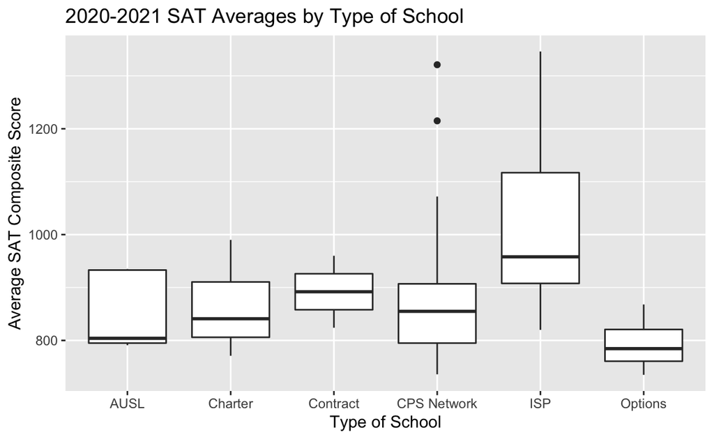

```r
#investigating based on 2020-2021 School Year

CPS_SAT_20_21_plot <- CPS_SAT_20_21|>
  select(`School Year`== "2020-2021")|>
  group_by( `Type of School`)|>
  ggplot( data = CPS_SAT_20_21,
          mapping = aes(x = `Type of School`, y = `Average Composite Score`)) +
  geom_boxplot(na.rm = TRUE) +
  labs( title = "2020-2021 SAT Averages by Type of School",
    x = "Type of School",
    y = "Average SAT Composite Score"
  )

CPS_SAT_20_21_plot
```

#Calculating the Average Composite Score by Type of School Tibble

```r
#Average of the `Average Composite Scores` by `Type of School`

avg_sat_table_20_21<- CPS_SAT_20_21 |>
  group_by(`Type of School`)|>
  summarise(sat_avg = mean(`Average Composite Score`, na.rm = TRUE))|>
  pivot_wider(values_from = sat_avg, names_from = `Type of School`)

avg_sat_table_20_21
```

```
# A tibble: 1 × 6
   AUSL Charter Contract `CPS Network`   ISP Options
  <dbl>   <dbl>    <dbl>         <dbl> <dbl>   <dbl>
1  852.    855.      892          872. 1026.    794.
```

###Is there a difference between CPS Netowrk Schools and Charter Schools? I will be calculating the Average Treatment effect for the 2020-2021 School Year

```r
#Finding out the difference in averages between Charters and CPS Network
# this is the difference between the SAT SCORE OF CPS and a Charter

CPS_SAT_20_21|>
  group_by(`Type of School`)|>
  summarise(sat_avg = mean(`Average Composite Score`, na.rm = TRUE))|>
  pivot_wider(values_from = sat_avg, names_from = `Type of School`)
```

```
# A tibble: 1 × 6
   AUSL Charter Contract `CPS Network`   ISP Options
  <dbl>   <dbl>    <dbl>         <dbl> <dbl>   <dbl>
1  852.    855.      892          872. 1026.    794.
```

```r
sat_ate <- CPS_SAT_20_21|>
  group_by(`Type of School`)|>
  summarise(sat_avg = mean(`Average Composite Score`, na.rm = TRUE))|>
  pivot_wider(values_from = sat_avg, names_from = `Type of School`) |>
  mutate(sat_ate = `Charter` - `CPS Network`)|>
  pull(sat_ate)

sat_ate
```

```
[1] -16.32308
```

###Now let’s explore another variable:College readiness in the same manner that we did for the previous variable.

#Average Percent of College Readiness by Type of School in the 2020-2021 School Year

```r
college_readiness_average <- CPS_SAT_20_21|>
  group_by(`Type of School`)|>
  summarise(college_readiness_avg = mean(`Percent College Readiness` , na.rm = TRUE))

college_readiness_average
```

```
# A tibble: 6 × 2
  `Type of School` college_readiness_avg
  <chr>                            <dbl>
1 AUSL                             14.8
2 Charter                          12.5
3 Contract                         19.4
4 CPS Network                      17.3
5 ISP                              46.7
6 Options                           3.69
```

###Is there a benefit of going to a Charter School as opposed to a CPS Network School in the case of College Readiness? ATE Calculation amoung the 2020-2021 School Year for COllege Readiness

```r
#We will see if there is an average treatement effect for going to charter

CPS_SAT_20_21 |>
  group_by(`Type of School`)|>
  summarise(college_readiness_avg = mean(`Percent College Readiness` , na.rm = TRUE))|>
  pivot_wider(values_from = college_readiness_avg, names_from = `Type of School`)
```

```
# A tibble: 1 × 6
   AUSL Charter Contract `CPS Network`   ISP Options
  <dbl>   <dbl>    <dbl>         <dbl> <dbl>   <dbl>
1  14.8    12.5     19.4          17.3  46.7    3.69
```

```r
college_readiness_ate<- CPS_SAT_20_21 |>
  group_by(`Type of School`)|>
  summarise(college_readiness_avg = mean(`Percent College Readiness` , na.rm = TRUE))|>
  pivot_wider(values_from = college_readiness_avg, names_from = `Type of School`)|>
  mutate(college_readiness_ate = `Charter` - `CPS Network`)|>
  pull(college_readiness_ate)

college_readiness_ate
```

```
[1] -4.770769
```

###After looking at this subsequent variable of College Readiness, which is measured in percents, we are able to see that the average college readiness per type of school varies slightly. It seems that CPS Network schools are on aberage 17.3 percent in College Readiness, while the Charter Schools are 12.5 percent. When calculating the ATE as the Treatment is going to a Charter School and the control is the CPS Network school. The ATE for college readiness is -4.770769, this meaning that on average a Charter student is -4.70769 less college ready than a CPS Network Student.

### Lets Create a Bootstrap to find out the various quantiles of the averages of different types of Schools in the School year 2020-2021. Lets see what the lower and higher confidence intervals can show us

```r
library(infer)
set.seed(02138)

ate_boots_20_21<- CPS_SAT_20_21|>
  rep_slice_sample(prop = 1, replace = TRUE, reps = 1000)|>
  group_by(replicate, `Type of School`)|>
  summarise(sat_avg = mean(`Average Composite Score`, na.rm = TRUE))|>
  pivot_wider(values_from = sat_avg , names_from = `Type of School`)|>
  mutate(sat_ate = `Charter` - `CPS Network`)



ate_sat_95_20_21 <- ate_boots_20_21|>
  ungroup(replicate)|>
  summarize(
    lower_ci = quantile(sat_ate, probs = .025),
    upper_ci = quantile(sat_ate, probs = 0.975)
  )

ate_sat_95_20_21
```

```
# A tibble: 1 × 2
  lower_ci upper_ci
     <dbl>    <dbl>
1    -46.7     15.7
```

#Lets analyze 2017-2018 school year, will we be able to see a change over the years when looking at the most recent 2020-2021? Lets create another bootstap for the 2017-2018 School Year. What will the upper and lower quantiles tell us?

```r
library(infer)
set.seed(02138)

CPS_SAT_17_18 <- CPS_SAT|>
  filter(`School Year` == "2017-2018")



ate_boots_17_18<- CPS_SAT_17_18|>
  rep_slice_sample(prop = 1, replace = TRUE, reps = 1000)|>
  group_by(replicate, `Type of School`)|>
  summarise(sat_avg = mean(`Average Composite Score`, na.rm = TRUE))|>
  pivot_wider(values_from = sat_avg , names_from = `Type of School`)|>
  mutate(sat_ate = `Charter` - `CPS Network`)


ate_sat_95_17_18 <- ate_boots_17_18|>
  ungroup(replicate)|>
  summarize(
    lower_ci = quantile(sat_ate, probs = .025),
    upper_ci = quantile(sat_ate, probs = 0.975)
  )

ate_sat_95_17_18
```

```
# A tibble: 1 × 2
  lower_ci upper_ci
     <dbl>    <dbl>
1    -9.83     60.5
```

### Lets compare the performance of different Types of Schools in 2017-2018 alongside the 2020-2021 Plot we had previously made

Trying to compare the 2020-2021 SAT to 2017 to 2018

###Data from 2020-2021

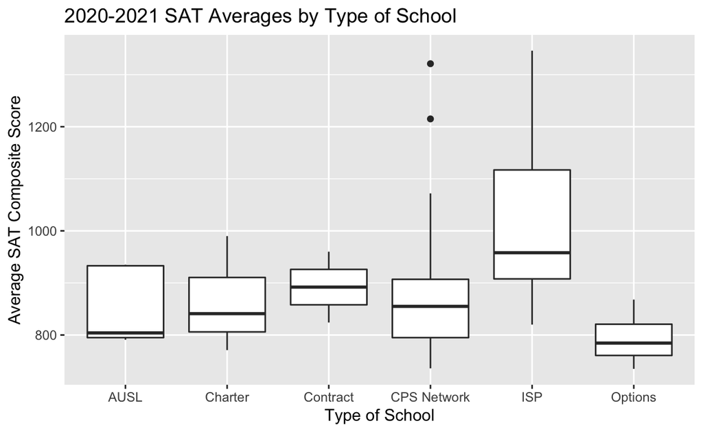

```r
CPS_SAT_20_21_plot <- CPS_SAT_20_21|>
  select(`School Year`== "2020-2021")|>
  group_by( `Type of School`)|>
  ggplot( data = CPS_SAT_20_21,
          mapping = aes(x = `Type of School`, y = `Average Composite Score`)) +
  geom_boxplot(na.rm = TRUE) +
  labs( title = "2020-2021 SAT Averages by Type of School",
    x = "Type of School",
    y = "Average SAT Composite Score"
  )



CPS_SAT_20_21_plot
```

```r
CPS_SAT_20_21|>
  group_by(`Type of School`)|>
  summarise(sat_avg = mean(`Average Composite Score`, na.rm = TRUE))|>
  pivot_wider(values_from = sat_avg, names_from = `Type of School`)
```

```
# A tibble: 1 × 6
   AUSL Charter Contract `CPS Network`   ISP Options
  <dbl>   <dbl>    <dbl>         <dbl> <dbl>   <dbl>
1  852.    855.      892          872. 1026.    794.
```

###Data from 2017-2018

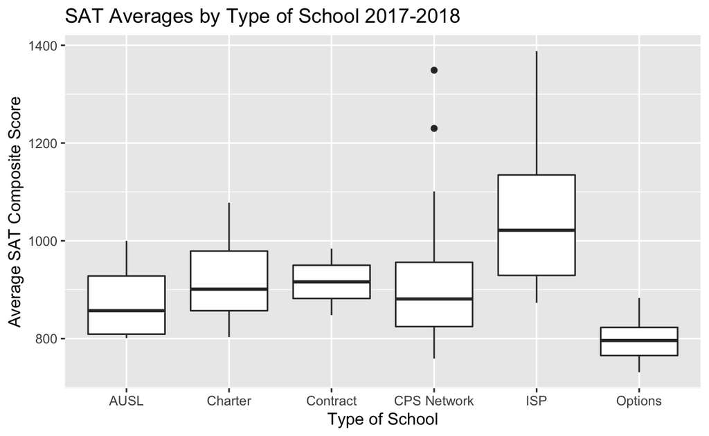

```r
CPS_SAT_17_18 <- CPS_SAT|>
  filter(`School Year` == "2017-2018")

CPS_SAT_17_18_plot <-CPS_SAT_17_18|>
  group_by(`Type of School`)|>
  ggplot( data = CPS_SAT_17_18,
          mapping = aes(x = `Type of School`, y = `Average Composite Score`)) +
  geom_boxplot(na.rm = TRUE) +
  labs( title = "SAT Averages by Type of School 2017-2018 ",
    x = "Type of School",
    y = "Average SAT Composite Score"
  )
CPS_SAT_17_18_plot
```

```r
avg_sat_table_17_18<- CPS_SAT_17_18 |>
  group_by(`Type of School`)|>
  summarise(sat_avg = mean(`Average Composite Score`, na.rm = TRUE))|>
  pivot_wider(values_from = sat_avg, names_from = `Type of School`)

avg_sat_table_17_18
```

```
# A tibble: 1 × 6
   AUSL Charter Contract `CPS Network`   ISP Options
  <dbl>   <dbl>    <dbl>         <dbl> <dbl>   <dbl>
1   879    926.      916          901. 1059.    794.
```

###In order to try to find out if we are able to determine a correlation among the percent of college readiness and SAT scores. I will run a linear regression for both 2017-2018 school year and the 2020-2021 school year comparing the intercepts and coefficient.

#Linear model for 2017-2018

```r
sat.app.17_18 <- lm(`Average Composite Score`~`Percent College Readiness`, data = CPS_SAT_17_18)

sat.app.17_18
```

```
Call:
lm(formula = `Average Composite Score` ~ `Percent College Readiness`,
    data = CPS_SAT_17_18)

Coefficients:
                (Intercept)  `Percent College Readiness`
                    791.495                        4.568
```

[figure not shown]

```r
sat.app.17_18_graph<-sat.app.17_18|>
  ggplot( data = CPS_SAT_17_18,
          mapping = aes(x = `Percent College Readiness`, y = `Average Composite Score`)) +
  geom_point(aes(color = `Type of School`), na.rm = TRUE)+ geom_smooth(na.rm = TRUE) + labs(title = "2020-2021 SAT and College Readiness")

sat.app.17_18_graph
```

```r
library(broom)
glance(sat.app.17_18)
```

```
# A tibble: 1 × 12
  r.squared adj.r.s…¹ sigma stati…²   p.value    df logLik   AIC   BIC
      <dbl>     <dbl> <dbl>   <dbl>     <dbl> <dbl>  <dbl> <dbl> <dbl>
1     0.933     0.933  29.7   2369. 2.39e-101     1  -822. 1650. 1659.
# … with 3 more variables: deviance <dbl>, df.residual <int>,
#   nobs <int>, and abbreviated variable names ¹adj.r.squared,
#   ²statistic
```

#Linear Model for 2020-2021

```r
sat.app.20_21 <-lm(`Average Composite Score`~`Percent College Readiness`, data = CPS_SAT_20_21)

sat.app.20_21
```

```
Call:
lm(formula = `Average Composite Score` ~ `Percent College Readiness`,
    data = CPS_SAT_20_21)

Coefficients:
                (Intercept)  `Percent College Readiness`
                    787.949                        4.921
```

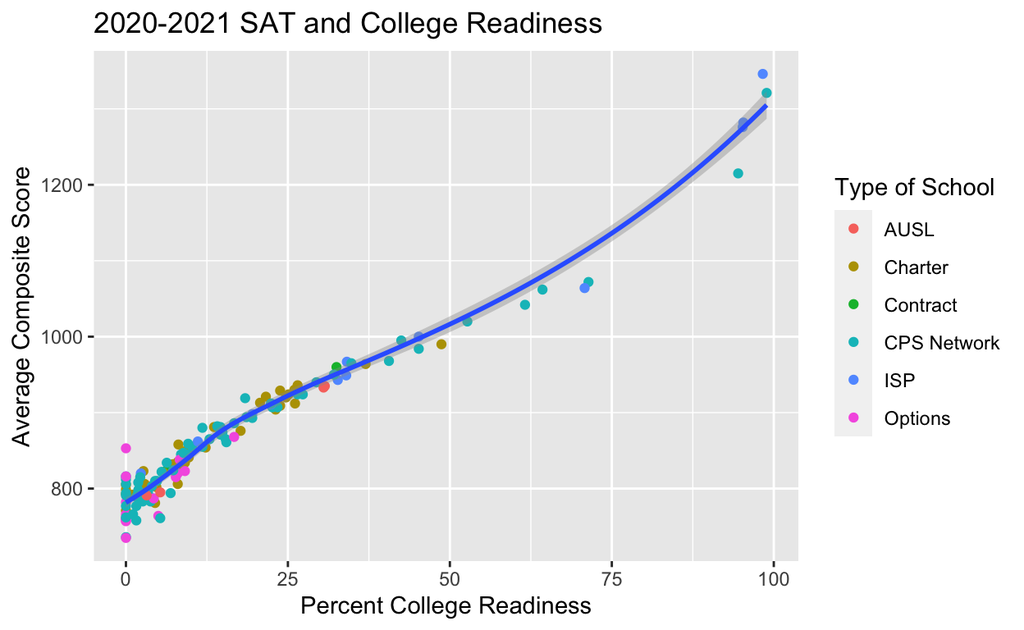

```r
sat.app.20_21_graph <- sat.app.20_21|>
  ggplot(data = CPS_SAT_20_21,
          mapping = aes(x = `Percent College Readiness`, y = `Average Composite Score`)) +  geom_point(aes(color = `Type of School`),na.rm = TRUE) + geom_smooth(na.rm = TRUE)+ labs(title = "2020-2021 SAT and College Readiness")

sat.app.20_21_graph
```

```r
library(broom)
glance(sat.app.20_21)
```

```
# A tibble: 1 × 12
  r.squared adj.r.sq…¹ sigma stati…²  p.value    df logLik   AIC   BIC
      <dbl>      <dbl> <dbl>   <dbl>    <dbl> <dbl>  <dbl> <dbl> <dbl>
1     0.955      0.955  23.1   2935. 2.10e-94     1  -633. 1271. 1280.
# … with 3 more variables: deviance <dbl>, df.residual <int>,
#   nobs <int>, and abbreviated variable names ¹adj.r.squared,
#   ²statistic
```